# Assignment 4 - Urban Growth Modelling

Anaushka Goyal and Grace Rogers

May 10th, 2025

# *Overview*

*This growth model utilizes land cover change scenario-based forecasting to estimate future growth projections in the greater Charlotte region, one of the largest and fastest growing areas of the US, to help build the case for expanding Charlotte’s Lynx light rail line*.

# 1. Setup - Loading Libraries and Functions

```r
library(tidyverse)
library(sf)
library(raster)
library(kableExtra)
library(tidycensus)
library(tigris)
library(FNN)
library(caret)
library(yardstick)
library(plotROC)
library(ggrepel)
library(pROC)
library(grid)
library(gridExtra)
library(viridis)
library(igraph)
library(mapview)
library(FedData)


palette2 <- c("#1b9e77", "#d95f02")
palette4 <- c("#66c2a5", "#41b6c4", "#2b8cbe", "#d95f02")
palette5 <- c("#edf8fb", "#b2e2e2", "#66c2a4", "#2b8cbe", "#fc8d62")
palette10 <- c("#f1eef6", "#d0d1e6", "#a6bddb", "#67a9cf", "#1c9099",
               "#41b6c4", "#66c2a5", "#fc8d62", "#e34a33", "#b30000")
```

## 1.1. Loading Custom build functions

```r
#this function converts a column in to quintiles. It is used for mapping.
quintileBreaks <- function(df,variable) {
    as.character(quantile(df[[variable]],
                          c(.01,.2,.4,.6,.8),na.rm=T))
}

#This function can be used to convert a polygon sf to centroids xy coords.
xyC <- function(aPolygonSF) {
  as.data.frame(
    cbind(x=st_coordinates(st_centroid(aPolygonSF))[,1],
          y=st_coordinates(st_centroid(aPolygonSF))[,2]))
}

#this function convert a raster to a data frame so it can be plotted in ggplot
rast <- function(inRaster) {
  data.frame(
    xyFromCell(inRaster, 1:ncell(inRaster)),
    value = getValues(inRaster)) }

# knn distance function

nn_function <- function(measureFrom,measureTo,k) {
  #convert the sf layers to matrices
  measureFrom_Matrix <-
    as.matrix(measureFrom)
  measureTo_Matrix <-
    as.matrix(measureTo)
  nn <-
    get.knnx(measureTo, measureFrom, k)$nn.dist
    output <-
    as.data.frame(nn) %>%
    rownames_to_column(var = "thisPoint") %>%
    gather(points, point_distance, V1:ncol(.)) %>%
    arrange(as.numeric(thisPoint)) %>%
    group_by(thisPoint) %>%
    summarize(pointDistance = mean(point_distance)) %>%
    arrange(as.numeric(thisPoint)) %>%
    dplyr::select(-thisPoint) %>%
    pull()

  return(output)
}

aggregateRaster <- function(inputRasterList, theFishnet) {
  #create an empty fishnet with the same dimensions as the input fishnet
  theseFishnets <- theFishnet %>% dplyr::select()
  #for each raster in the raster list
  for (i in inputRasterList) {
  #create a variable name corresponding to the ith raster
  varName <- names(i)
  #convert raster to points as an sf
    thesePoints <-
      rasterToPoints(i) %>%
      as.data.frame() %>%
      st_as_sf(coords = c("x", "y"), crs = st_crs(theFishnet)) %>%
      filter(.[[1]] == 1)
  #aggregate to the fishnet
    thisFishnet <-
      aggregate(thesePoints, theFishnet, length) %>%
      mutate(!!varName := ifelse(is.na(.[[1]]),0,1))
  #add to the larger fishnet
    theseFishnets <- cbind(theseFishnets,thisFishnet)
  }
  #output all aggregates as one large fishnet
   return(theseFishnets)
  }
```

# 2. Loading Land Cover and MSA data

This model uses historical data from 2011 and 2019 to predict land change for 2027 in the greater Charlotte region, the boundary of which is defined as the Charlotte-Concord-Gastonia, NC-SC Metropolitan Statistical Area (MSA). Data come from the U.S. Census Bureau and land cover data come from the U.S. Geological Survey (USGS)’s National Land Cover Database (NLCD). Since the region spans two states, census data were retrieved separately for each state and then combined into a single dataset for spatial analysis. In North Carolina, the selected counties are Mecklenburg, Cabarrus, Gaston, Iredell, Lincoln, Rowan, Union, and Anson. In South Carolina, the included counties are York, Chester, and Lancaster.

## 2.1. Load the study area MSA

```r
census_api_key("02524912081801068f04f286a086d19e9fc641ca", install = TRUE, overwrite = TRUE)
```

```
## [1] "02524912081801068f04f286a086d19e9fc641ca"
```

```r
readRenviron("~/.Renviron")

# Define counties by state
charlotte_msa_counties <- list(
  NC = c("Mecklenburg", "Cabarrus", "Gaston", "Iredell", "Lincoln",
         "Rowan", "Union", "Anson"),
  SC = c("091", "023", "057")
)

# Variable to download
acsVariables <- c(totpop = "B01001_001")


# Pull data by state and county
msa_tracts <- map_dfr(names(charlotte_msa_counties), function(st) {
  get_acs(
    geography = "tract",
    variables = acsVariables,
    state = st,
    county = charlotte_msa_counties[[st]],
    survey = "acs5",
    year = 2019,
    output = "wide",
    geometry = TRUE
  )
}) %>%
  st_transform(32119)  # NAD83 / North Carolina (ft)
```

[output not shown]

[output not shown]

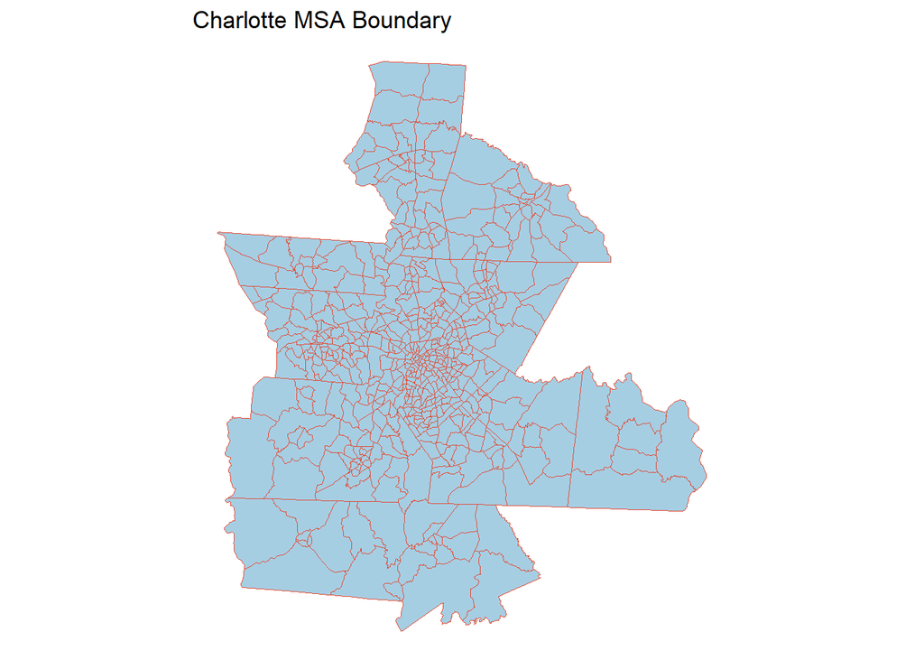

```r
# Create unified boundary
msa_boundary <- msa_tracts %>%
  st_union() %>%
  st_as_sf()

ggplot() +
    geom_sf(data = msa_boundary, fill = "#a6cee3", color = "#1f78b4") +
  geom_sf(data=msa_tracts, fill= NA,  color= "#e34a33") +
  labs(title = "Charlotte MSA Boundary") +
  theme_void()
```

## 2.2. Load Land Cover for t1 and t2

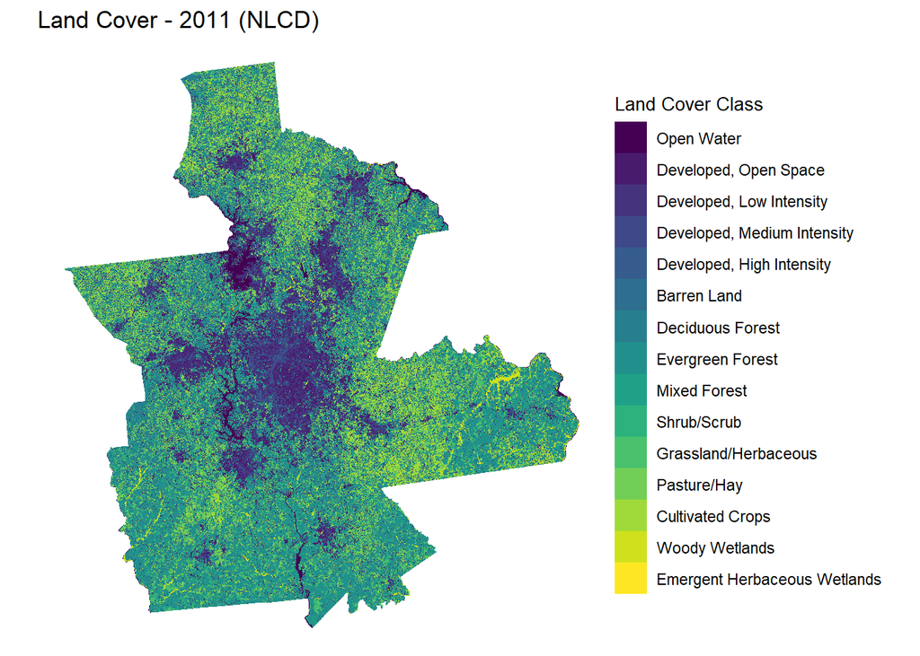

```r
lc_2011 <- get_nlcd(
  template = msa_boundary,
  label = "charlotte_lc_2011",
  year = 2011) %>%
  raster(.)


lc_2011_df <- as.data.frame(rasterToPoints(lc_2011))
colnames(lc_2011_df) <- c("x", "y", "landcover")


landcover_labels <- c(
  "11" = "Open Water",
  "21" = "Developed, Open Space",
  "22" = "Developed, Low Intensity",
  "23" = "Developed, Medium Intensity",
  "24" = "Developed, High Intensity",
  "31" = "Barren Land",
  "41" = "Deciduous Forest",
  "42" = "Evergreen Forest",
  "43" = "Mixed Forest",
  "52" = "Shrub/Scrub",
  "71" = "Grassland/Herbaceous",
  "81" = "Pasture/Hay",
  "82" = "Cultivated Crops",
  "90" = "Woody Wetlands",
  "95" = "Emergent Herbaceous Wetlands"
)


ggplot(lc_2011_df, aes(x = x, y = y, fill = factor(landcover))) +
  geom_raster() +
  scale_fill_manual(
    name = "Land Cover Class",
    values = viridis::viridis(length(landcover_labels)),
    labels = landcover_labels[levels(factor(lc_2011_df$landcover))]
  ) +
  coord_equal() +
  labs(title = "Land Cover - 2011 (NLCD)", x = NULL, y = NULL) +
  theme_void() +
  theme(legend.position = "right", legend.title = element_text(size = 10))
```

The above map shows the distribution of landcover classes in the study area.

```r
lc_2019 <- get_nlcd(
    template = msa_boundary,
    label = "charlotte_lc_2019",
    year = 2019
  ) %>%
  raster(.)
```

# 3. Detecting Land Cover Conversion

Here, we detect land cover change between 2011 and 2019 that has transitioned from undeveloped to developed land.

## 3.1. Resampling Rasters

```r
lc_2011_rs <- aggregate(lc_2011, fact = 30, fun = "modal")

lc_2019_rs <- aggregate(lc_2019, fact = 30, fun = "modal")
```

## 3.2. Reclassifying As Developed and Undeveloped

```r
reclassMatrix <-
  matrix(c(
    0,12,0,
    12,24,1,
    24,Inf,0),
  ncol=3, byrow=T)
```

The above matrix reclassifies urban areas as 1 and everything else as 0.

```r
developed_2011 <-
  reclassify(lc_2011_rs, reclassMatrix)

developed_2019 <-
  reclassify(lc_2019_rs, reclassMatrix)
```

The above creates binary rasters: 1 for developed, 0 for undeveloped.

```r
development_change <- developed_2011 + developed_2019
```

Now, we are comparing two rasters cell by cell. Since we only have 1 and 0 in our rasters now, 0 + 0 = 0 means there was no change in undeveloped land, whereas 0 + 1 = 1 means land went from undeveloped to developed. We are not interested in developed land that remains developed (1 + 1 = 2), or developed land that has transitioned to undeveloped (1 + 0 = 1). For this growth projection, we are only interested in rasters that converted from 0 to 1 (undeveloped to developed).

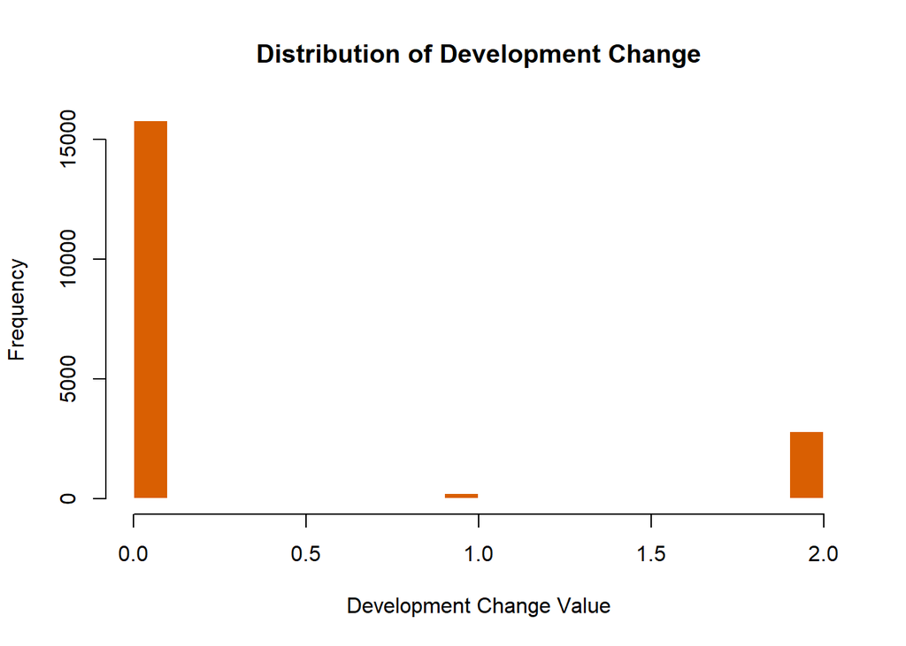

```r
hist(development_change,
     main = "Distribution of Development Change",
     xlab = "Development Change Value",
     col = palette2[2],   # Use the darker color for developed (value = 1)
     border = "white")
```

```r
development_change[development_change != 1] <- NA
```

Here, we drop all values that are not 1, since this is the only change we are interested in forecasting to 2027.

## 3.3. Examining Land Cover Change

Let’s use Mapview to take a look at the `development_change` raster.

```r
mapView(development_change,
        col.regions = palette2,
        na.color = "transparent",
        layer.name = "Development Change")
```

[interactive chart not shown]

The resulting map shows all raster grid cells in the MSA which were undeveloped in 2011 and transitioned to developed by 2019.

# 4. Creating the Fishnet

```r
msa_fishnet <-
  st_make_grid(msa_boundary %>%
                     st_transform(crs(development_change)),
                 cellsize = res(development_change)[1],
                 square = TRUE) %>%
  st_sf() %>%
  st_intersection(., msa_boundary %>%
                    dplyr::select(x) %>%
                         st_transform(crs(development_change))) %>%
  mutate(uniqueID = rownames(.))
```

# 5. Join Raster Data to the Fishnet

## 5.1. Aggregating LC Change to fishnet

```r
changePoints <-
  rasterToPoints(development_change) %>%
  as.data.frame() %>%
  st_as_sf(coords = c("x", "y"),
           crs = st_crs(msa_fishnet))

fishnet <-
  aggregate(changePoints,
            msa_fishnet,
            FUN=sum) %>%
  mutate(development_change = ifelse(is.na(layer) == TRUE , 0, 1),
         development_change = as.factor(development_change)) %>%
  dplyr::select(-layer)
```

### 5.1.1. Plotting Development Change

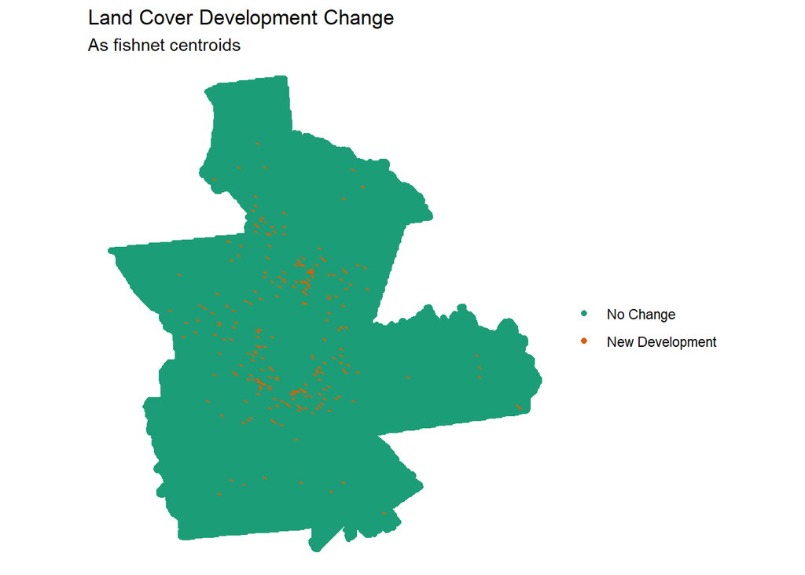

```r
ggplot() +
  geom_sf(data=msa_boundary %>%
            st_transform(crs(fishnet))) +
  geom_point(data=fishnet,
             aes(x=xyC(fishnet)$x,
                 y=xyC(fishnet)$y,
                 colour=development_change)) +
  scale_colour_manual(values = palette2,
                      labels=c("No Change","New Development"),
                      name = "") +
  labs(title = "Land Cover Development Change", subtitle = "As fishnet centroids") +
  theme_void()
```

## 5.2. Aggregating Batch Land Cover Data to the Fishnet

Here, we aggregate our 2011 raster land cover data into a few categories and combine this with our binary classification of land that was developed between 2011 and 2019 to see the amount and location of development based on specific land cover types.

### 5.2.1. Reclassifying land cover

We are going to recode our NLCD data into a few reduced categories to be used in our analysis. Here is the classification logic:

| Old_Classification | New_Classification |
| --- | --- |
| Open Space as well as Low, Medium and High Intensity Development | Developed |
| Deciduous, Evergreen, and Mixed Forest | Forest |
| Pasture/Hay and Cultivated Crops | Farm |
| Woody and Emergent Herbaceous Wetlands | Wetlands |
| Barren Land, Dwarf Scrub, and Grassland/Herbaceous | Other Undeveloped |
| Water | Water |

In the code block below, we create new rasters, descriptively called `developed_2011`, `forest_2011` etc , according to the NLCD codes that correspond to our classification scheme.

```r
developed_2011 <- lc_2011_rs  %in% c(21, 22, 23, 24)
forest_2011 <- lc_2011_rs %in% c(41, 42, 42)
farm_2011 <- lc_2011_rs %in% c(81, 82)
wetlands_2011 <- lc_2011_rs %in% c(90, 95)
otherUndeveloped_2011 <- lc_2011_rs %in% c(52, 71, 31)
water_2011 <- lc_2011_rs == 11

developed_2019 <- lc_2019_rs %in% c(21, 22, 23, 24)
forest_2019 <- lc_2019_rs %in% c(41, 42, 42)
farm_2019 <- lc_2019_rs %in% c(81, 82)
wetlands_2019 <- lc_2019_rs %in% c(90, 95)
otherUndeveloped_2019 <- lc_2019_rs %in% c(52, 71, 31)
water_2019 <- lc_2019_rs == 11
```

### 5.2.2. Aggregating Rasters to the Fishnet

```r
names(developed_2011) <- "developed_2011"
names(forest_2011) <- "forest_2011"
names(farm_2011) <- "farm_2011"
names(wetlands_2011) <- "wetlands_2011"
names(otherUndeveloped_2011) <- "otherUndeveloped_2011"
names(water_2011) <- "water_2011"

names(developed_2019) <- "developed_2019"
names(forest_2019) <- "forest_2019"
names(farm_2019) <- "farm_2019"
names(wetlands_2019) <- "wetlands_2019"
names(otherUndeveloped_2019) <- "otherUndeveloped_2019"
names(water_2019) <- "water_2019"
```

```r
rasterList_2011 <- c(developed_2011,
                   forest_2011,
                   farm_2011,
                   wetlands_2011,
                   otherUndeveloped_2011,
                   water_2011)

rasterList_2019 <- c(developed_2019,
                   forest_2019,
                   farm_2019,
                   wetlands_2019,
                   otherUndeveloped_2019,
                   water_2019)
```

```r
lcRasters_2011 <-
  aggregateRaster(rasterList_2011,
                  msa_fishnet) %>%
  dplyr::select(developed_2011,
                   forest_2011,
                   farm_2011,
                   wetlands_2011,
                   otherUndeveloped_2011,
                   water_2011) %>%
  mutate_if(is.numeric,as.factor)

lcRasters_2019 <-
  aggregateRaster(rasterList_2019,
                  msa_fishnet) %>%
  dplyr::select(developed_2019,
                   forest_2019,
                   farm_2019,
                   wetlands_2019,
                   otherUndeveloped_2019,
                   water_2019) %>%
  mutate_if(is.numeric,as.factor)
```

Finally, we take this data and map them to see where developed has occurred by land cover type.

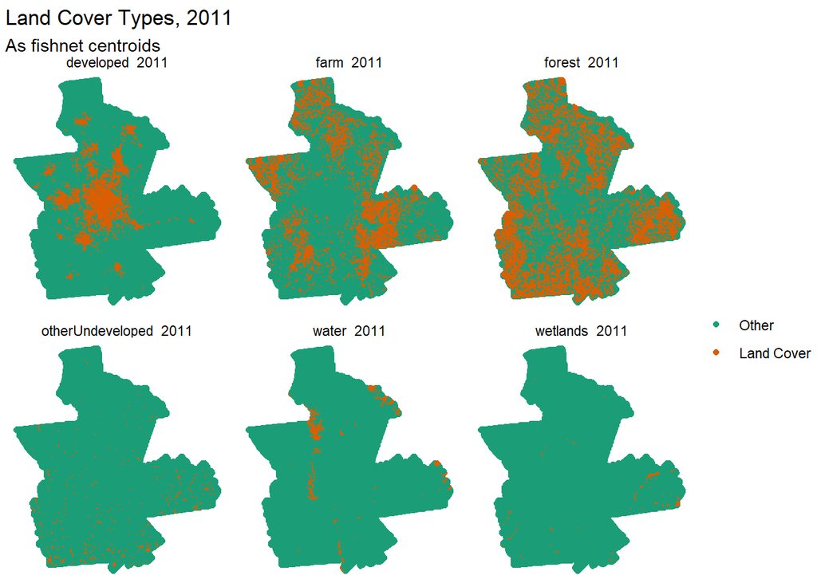

```r
lcRasters_2011 %>%
  st_centroid() %>%
 gather(key = "variable", value = "value", developed_2011:water_2011) %>%
  mutate(X = xyC(.)$x,
         Y = xyC(.)$y) %>%
  ggplot() +
    geom_sf(data=msa_fishnet) +
    geom_point(aes(X,Y, colour=as.factor(value))) +
    facet_wrap(~variable) +
    scale_colour_manual(values = palette2,
                        labels=c("Other","Land Cover"),
                        name = "") +
    labs(title = "Land Cover Types, 2011",
         subtitle = "As fishnet centroids") +
   theme_void()
```

# 6. Wrangle Census Data and Join To the Fishnet

## 6.1. Downloading Census Data via API

```r
acs_vars <- c("B02001_001E")

charlotte_msa_counties <- list(
  NC = c("Mecklenburg", "Cabarrus", "Gaston", "Iredell", "Lincoln",
         "Rowan", "Union", "Anson"),
  SC = c("091", "023", "057")  # York, Chester, Lancaster (FIPS)
)


charPop11 <- map_dfr(names(charlotte_msa_counties), function(st) {
  get_acs(
    geography = "tract",
    variables = acs_vars,
    year = 2011,
    state = st,
    county = charlotte_msa_counties[[st]],
    geometry = TRUE,
    output = "wide"
  )
}) %>%
  dplyr::select(GEOID, NAME, all_of(acs_vars)) %>%
  rename(pop_2011 = B02001_001E) %>%
  st_transform(st_crs(msa_fishnet)) %>%
  st_buffer(-1)
```

We do this once more for `t2`, in this case, 2019.

```r
charPop19 <- map_dfr(names(charlotte_msa_counties), function(st) {
  get_acs(
    geography = "tract",
    variables = acs_vars,
    year = 2019,
    state = st,
    county = charlotte_msa_counties[[st]],
    geometry = TRUE,
    output = "wide"
  )
}) %>%
  dplyr::select(GEOID, NAME, all_of(acs_vars)) %>%
  rename(pop_2019 = B02001_001E) %>%
  st_transform(st_crs(msa_fishnet)) %>%
  st_buffer(-1)
```

Then we can plot our data and see the spatial arrangement of population in our study area in t1 (2011) and t2 (2019).

One thing worth noting here is that the quantile symbology that we apply probably changes from t1 to t2 - so you can see that, on average, there was densification across the metro area on this time interval because the quantile ranges shift upwards.

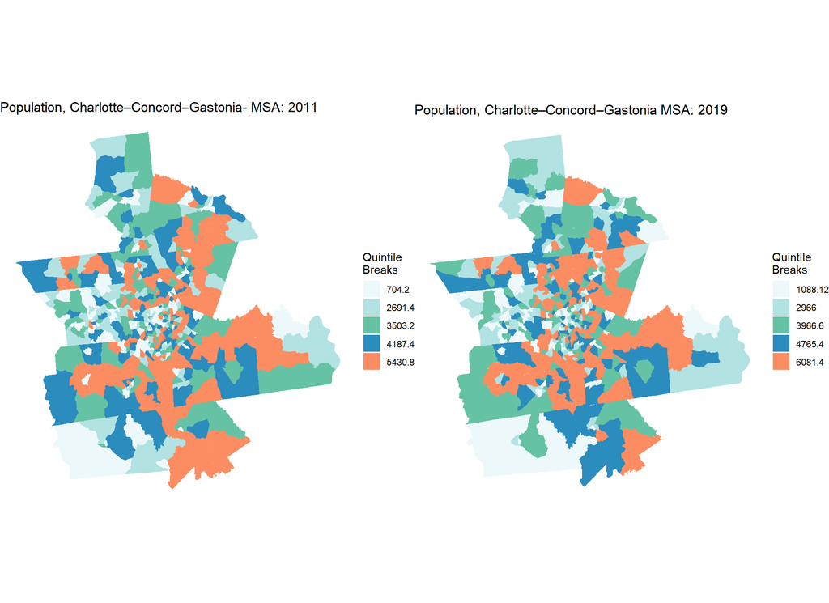

```r
grid.arrange(
ggplot() +
  geom_sf(data = charPop11, aes(fill=factor(ntile(pop_2011,5))), colour=NA) +
  scale_fill_manual(values = palette5,
                    labels=quintileBreaks(charPop11,"pop_2011"),
                   name="Quintile\nBreaks") +
  labs(title="Population, Charlotte–Concord–Gastonia- MSA: 2011") +
  theme_void(),

ggplot() +
  geom_sf(data = charPop19, aes(fill=factor(ntile(pop_2019,5))), colour=NA) +
  scale_fill_manual(values = palette5,
                    labels=quintileBreaks(charPop19,"pop_2019"),
                   name="Quintile\nBreaks") +
  labs(title="Population, Charlotte–Concord–Gastonia MSA: 2019") +
  theme_void(), ncol=2)
```

## 6.2. Aggregate Census Data with Aerially Weighted Interpolation

Here we use Areal Weighted Interpretation (AWI) to distribute the population within each tract across the fishnet grid cells; this method assumes that population is distributed evenly across the tract, which is reasonable here because we are not measuring population as an outcome that requires meaningful precision in this analysis. The output is a new fishnet for each year that includes a population estimate within each tract.

```r
fishnetPopulation11 <-
  st_interpolate_aw(charPop11["pop_2011"],
                    msa_fishnet,
                    extensive=TRUE) %>%
  st_centroid() %>%
  st_join(msa_fishnet, ., join = st_intersects) %>%
  mutate(pop_2011 = replace_na(pop_2011,0)) %>%
  dplyr::select(pop_2011)
```

We repeat the process for our `t2` data.

```r
fishnetPopulation19 <-
  st_interpolate_aw(charPop19["pop_2019"],
                    msa_fishnet,
                    extensive=TRUE) %>%
  st_centroid() %>%
  st_join(msa_fishnet, ., join = st_intersects) %>%
  mutate(pop_2019 = replace_na(pop_2019,0)) %>%
  dplyr::select(pop_2019)
```

How do these data look when we map them out and compare them to the census vectors? We can see that the modifiable aerial unit issue - where smaller tracts are higher density because of the logic of tract-drawing - no longer distorts the picture - we see increased density in the center, where we expect it.

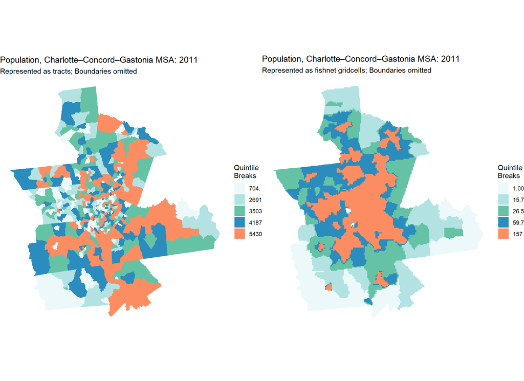

```r
grid.arrange(
ggplot() +
  geom_sf(data=charPop11, aes(fill=factor(ntile(pop_2011,5))),colour=NA) +
  scale_fill_manual(values = palette5,
                    labels=substr(quintileBreaks(charPop11,"pop_2011"),1,4),
                   name="Quintile\nBreaks") +
  labs(title="Population, Charlotte–Concord–Gastonia MSA: 2011",
       subtitle="Represented as tracts; Boundaries omitted") +
  theme_void(),

  ggplot() +
  geom_sf(data=fishnetPopulation11,
         aes(fill=factor(ntile(pop_2011,5))),colour=NA) +
  scale_fill_manual(values = palette5,
                   labels=substr(quintileBreaks(fishnetPopulation11,"pop_2011"),1,4),
                   name="Quintile\nBreaks") +
  labs(title="Population, Charlotte–Concord–Gastonia MSA: 2011",
       subtitle="Represented as fishnet gridcells; Boundaries omitted") +
  theme_void(), ncol=2)
```

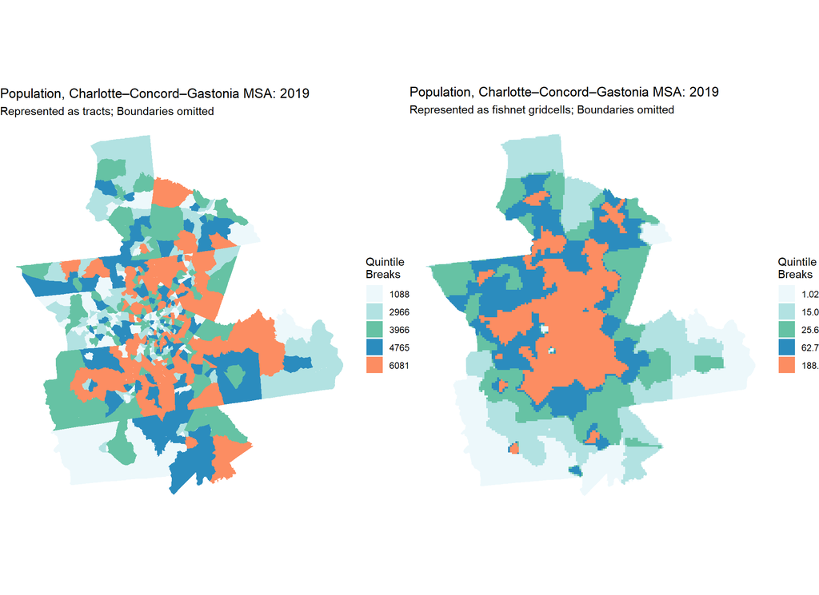

```r
grid.arrange(
ggplot() +
  geom_sf(data=charPop19, aes(fill=factor(ntile(pop_2019,5))),colour=NA) +
  scale_fill_manual(values = palette5,
                    labels=substr(quintileBreaks(charPop19,"pop_2019"),1,4),
                   name="Quintile\nBreaks") +
  labs(title="Population, Charlotte–Concord–Gastonia MSA: 2019",
       subtitle="Represented as tracts; Boundaries omitted") +
  theme_void(),

  ggplot() +
  geom_sf(data=fishnetPopulation19,
         aes(fill=factor(ntile(pop_2019,5))),colour=NA) +
  scale_fill_manual(values = palette5,
                   labels=substr(quintileBreaks(fishnetPopulation19,"pop_2019"),1,4),
                   name="Quintile\nBreaks") +
  labs(title="Population, Charlotte–Concord–Gastonia MSA: 2019",
       subtitle="Represented as fishnet gridcells; Boundaries omitted") +
  theme_void(), ncol=2)
```

# 7. Transportation And Infrastructure

Transportation access in the Charlotte MSA is critical for the growing economy, which includes a robust manufacturing sector in addition to financial, tech, and service-based employers. Automobiles are the primary method of transportation for the majority of residents, but Mecklenburg County also operates a transit system that includes two light rail lines and a bus system.

## 7.1. Download Highways

First highway vectors (`primary_roads`) are downloaded from the `Tigris` package - we project the data and subset it to the study area using `st_intersection`.

```r
charHighways <- bind_rows(
  primary_secondary_roads(state = "NC"),
  primary_secondary_roads(state = "SC")
) %>%
  st_transform(st_crs(msa_boundary)) %>%  # Match to MSA CRS
  st_intersection(msa_boundary) %>%       # Clip to MSA
  st_transform(st_crs(fishnet))           # Match CRS to fishnet
```

Let’s make a map and examine the spatial relationship between highways and development.

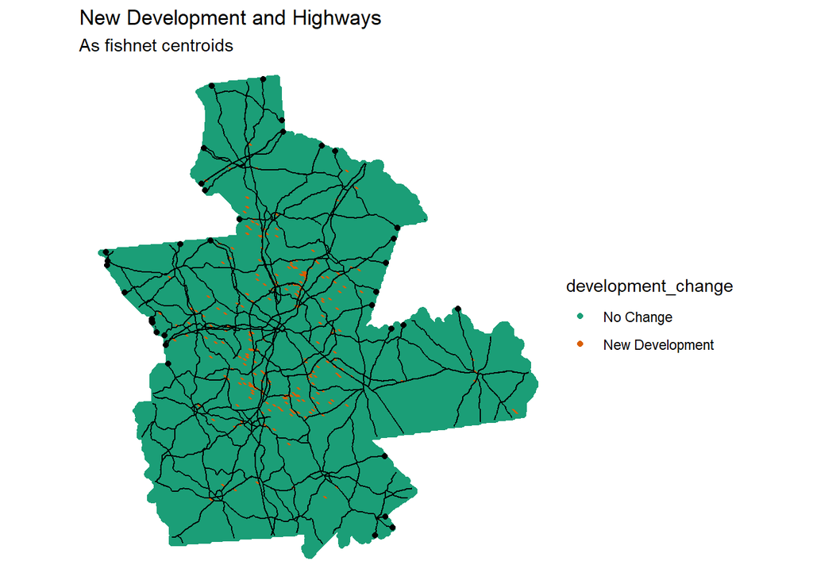

```r
ggplot() +
  geom_point(data=fishnet,
             aes(x=xyC(fishnet)[,1], y=xyC(fishnet)[,2],colour=development_change),size=1.5) +
  geom_sf(data=charHighways) +
  scale_colour_manual(values = palette2,
                      labels=c("No Change","New Development")) +
  labs(title = "New Development and Highways",
       subtitle = "As fishnet centroids") +
  theme_void()
```

## 7.2. Calcuate Distance to Highways

Here, we pull highway data from 2011.

```r
highwayPoints_fishnet_2011 <- msa_fishnet %>%
  st_centroid() %>%
  mutate(distance_highways_2011 = as.numeric(st_distance(., st_union(charHighways) %>%
                                                      st_transform(st_crs(msa_fishnet))))) %>%
  as.data.frame() %>%
  dplyr::select(-geometry) %>%
  left_join(msa_fishnet, .) %>%
  st_as_sf()

highwayPoints_fishnet_2019 <- highwayPoints_fishnet_2011 %>%
  rename(distance_highways_2019 = distance_highways_2011)
```

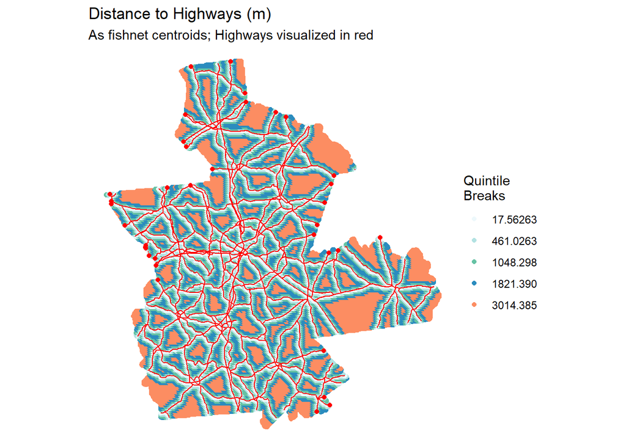

```r
ggplot() +
  geom_sf(data=msa_boundary %>% st_transform(st_crs(highwayPoints_fishnet_2011))) +
  geom_point(data=highwayPoints_fishnet_2011, aes(x=xyC(highwayPoints_fishnet_2011)[,1],
                                             y=xyC(highwayPoints_fishnet_2011)[,2],
                 colour=factor(ntile(distance_highways_2011,5))),size=1.5) +
  scale_colour_manual(values = palette5,
                      labels=substr(quintileBreaks(highwayPoints_fishnet_2011,"distance_highways_2011"),1,8),
                      name="Quintile\nBreaks") +
  geom_sf(data=charHighways, colour = "red") +
  labs(title = "Distance to Highways (m)",
       subtitle = "As fishnet centroids; Highways visualized in red") +
  theme_void()
```

# 8. Calculate spatial lag of development

In this step, we calculate the average distance to each grid cell’s 2 nearest developed grid cells in 2011 using a new variable created by our k-nearest-neighbors custom function (`nn_function`) for spatial lag, `lagDevelopment_2011` and `lagDevelopment_2019`.

```r
fishnet$lagDevelopment_2011 <-
    nn_function(fishnet %>%
                  st_centroid() %>%
                  st_coordinates() %>%
                  as.data.frame(),
                lcRasters_2011 %>%
                  filter(developed_2011 == 1) %>%
                  st_centroid() %>%
                  st_coordinates() %>%
                  as.data.frame(),
                2)

fishnet$lagDevelopment_2019 <-
    nn_function(fishnet %>%
                  st_centroid() %>%
                  st_coordinates() %>%
                  as.data.frame(),
                lcRasters_2019 %>%
                  filter(developed_2019 == 1) %>%
                  st_centroid() %>%
                  st_coordinates() %>%
                  as.data.frame(),
                2)
```

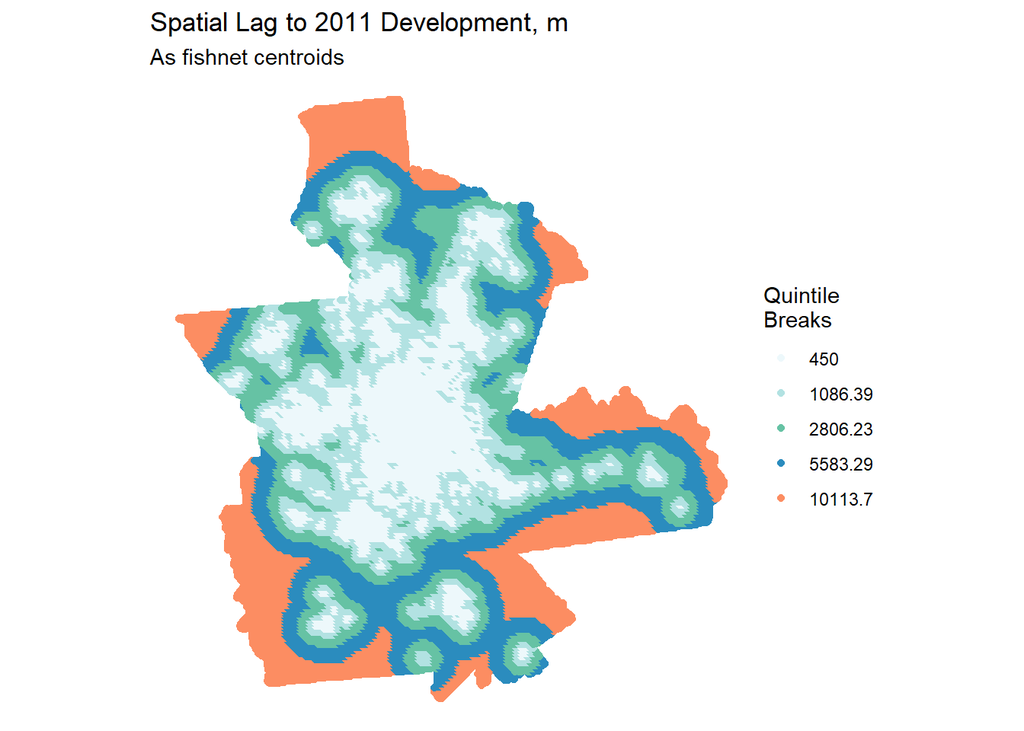

```r
ggplot() +
  geom_sf(data=msa_boundary %>% st_transform(st_crs(fishnet))) +
  geom_point(data=fishnet,
             aes(x=xyC(fishnet)[,1], y=xyC(fishnet)[,2],
                 colour=factor(ntile(lagDevelopment_2011,5))), size=1.5) +
  scale_colour_manual(values = palette5,
                     labels=substr(quintileBreaks(fishnet,"lagDevelopment_2011"),1,7),
                     name="Quintile\nBreaks") +
  labs(title = "Spatial Lag to 2011 Development, m",
       subtitle = "As fishnet centroids") +
  theme_void()
```

# 9. Political Boundaries

The MSA includes Mecklenburg, Cabarrus, Gaston, Iredell, Lincoln, Rowan, Union, and Anson Counties in NC and York, Chester, and Lancaster counties in SC.

```r
options(tigris_class = "sf")

nc_counties <- counties(state = "NC") %>% st_as_sf()
sc_counties <- counties(state = "SC") %>% st_as_sf()


all_counties <- bind_rows(nc_counties, sc_counties) %>%
  st_transform(st_crs(msa_fishnet))


studyAreaCounties <- all_counties %>%
  filter(
    (STATEFP == "37" & NAME %in% c("Mecklenburg", "Cabarrus", "Gaston", "Iredell",
                                   "Lincoln", "Rowan", "Union", "Anson")) |
    (STATEFP == "45" & COUNTYFP %in% c("091", "023", "057"))  # York, Chester, Lancaster
  )
```

We spatially join the `studyAreaCounties` object to our fishnet and create a `countyFishnet` where each cell is imparted with the name of the county it belongs to.

```r
countyFishnet <- msa_fishnet %>%
  st_join(., studyAreaCounties %>%
            dplyr::select(NAME)) %>%
  as.data.frame() %>%
  dplyr::select(uniqueID, NAME) %>%
  left_join(msa_fishnet, .) %>%
  st_as_sf() %>%
  group_by(uniqueID) %>%
  slice(1) %>%
  ungroup() %>%
  arrange(as.numeric(uniqueID))
```

# 10. Creating Our Data Set for Modeling

Here we compile our data to create a model which we can train for a future scenario projection. This includes:

For t1 (2011): - fishnet - highwayPoints_fishnet_2011 - fishnetPopulation11 - lcRasters_2011 - countyFishnet

For t2 (2019): - fishnet - highwayPoints_fishnet_2019 - fishnetPopulation19 - lcRasters_2019 - countyFishnet

```r
dat_2011 <-
  cbind( fishnet, highwayPoints_fishnet_2011, fishnetPopulation11, lcRasters_2011, countyFishnet) %>%
  as.data.frame() %>%
  dplyr::select(uniqueID, development_change, lagDevelopment_2011, distance_highways_2011, pop_2011,
                developed_2011, forest_2011, farm_2011, wetlands_2011, otherUndeveloped_2011, water_2011,
                NAME, geometry) %>%
  filter(water_2011 == 0) %>%
  rename_with(~ str_remove(.x, "_2011"))

dat_2019 <-
  cbind( fishnet, highwayPoints_fishnet_2019, fishnetPopulation19, lcRasters_2019, countyFishnet) %>%
  as.data.frame() %>%
  dplyr::select(uniqueID, development_change, lagDevelopment_2019, distance_highways_2019, pop_2019,
                developed_2019, forest_2019, farm_2019, wetlands_2019, otherUndeveloped_2019, water_2019,
                NAME, geometry) %>%
  filter(water_2019 == 0)  %>%
  rename_with(~ str_remove(.x, "_2019"))
```

# 11. Feature Exploration

In this section we explore the extent to our possible predictors (distance to highways, spatial lag of development, and population change) are associated with development change. One note: In an initial run of the model, we did see that proximity to the Blue Line was a strong predictor of development between 2011 and 2019, but did not include the lines in our initial model after a conversation with Isabel. The Lynx Blue line was first built in 2007 and extended in 2018, while the Gold Line was completed in 2015. Because the transit infrastructure has not remained consistent throughout this time period, we did not include it here.

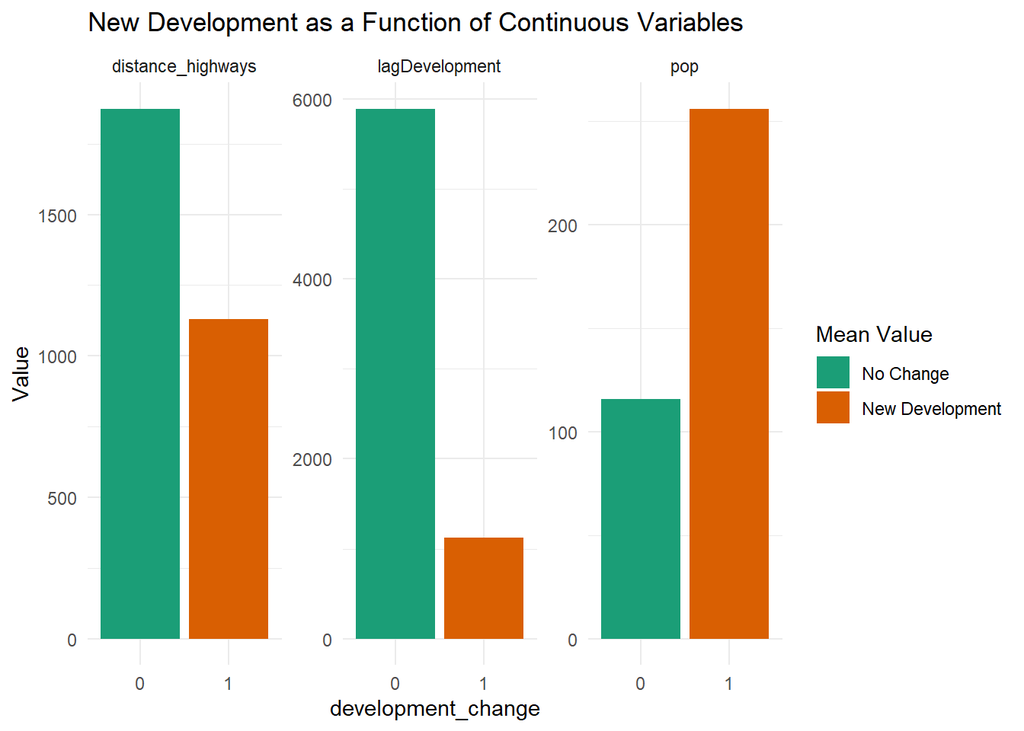

```r
dat_2011 %>%
  dplyr::select(distance_highways,lagDevelopment,development_change, pop) %>%
  gather(Variable, Value, -development_change) %>%
  ggplot(., aes(development_change, Value, fill=development_change)) +
    geom_bar(position = "dodge", stat = "summary", fun.y = "mean") +
    facet_wrap(~Variable, scales = "free") +
    scale_fill_manual(values = palette2,
                      labels=c("No Change","New Development"),
                      name="Mean Value") +
    labs(title="New Development as a Function of Continuous Variables") +
    theme_minimal()
```

This histogram shows that on average, land that was developed between 2011 and 2019 was closer to highways, closer to other development, and was in areas with higher populations, indicating densification over sprawl.

When we look at the type of land converted in this time interval, we see it was predominately forested land, with some farms converted and only marginal “Other undeveloped” land converted, per the table below.

```r
dat_2011 %>%
  dplyr::select(development_change, forest, farm, wetlands, otherUndeveloped) %>%
  gather(key = "Land_Cover_Type", Value, -development_change) %>%
     group_by(development_change, Land_Cover_Type) %>%
     summarize(n = sum(as.numeric(Value))) %>%
     ungroup() %>%
    mutate(Conversion_Rate = paste0(round(100 * n/sum(n), 2), "%")) %>%
    filter(development_change == 1) %>%
  dplyr::select(Land_Cover_Type,Conversion_Rate) %>%
  kable() %>% kable_styling(full_width = F)
```

| Land_Cover_Type | Conversion_Rate |
| --- | --- |
| farm | 0.25% |
| forest | 0.92% |
| otherUndeveloped | 0.04% |
| wetlands | 0% |

# 12. Modeling

Here, we train and test our model with an even 50% of data split between the training and test sets to help keep a fair number of 1s in our training set.

## 12.1. Splitting our data

```r
set.seed(3456)
trainIndex <-
  createDataPartition(dat_2011$otherUndeveloped, p = .50,
                                  list = FALSE,
                                  times = 1)
datTrain <- dat_2011[ trainIndex,]
datTest  <- dat_2011[-trainIndex,]
```

## 12.2. Specifying models

We estimate six separate `glm` models - adding new variables for each.

```r
Model1 <- glm(development_change ~ wetlands + forest  + farm +
                otherUndeveloped,
              family="binomial"(link="logit"), data = datTrain)

Model2 <- glm(development_change ~ wetlands + forest  + farm +
                otherUndeveloped + lagDevelopment,
              family="binomial"(link="logit"), data = datTrain)

Model3 <- glm(development_change ~ wetlands + forest  + farm +
                otherUndeveloped + lagDevelopment + pop,
              family="binomial"(link="logit"), data = datTrain)

Model4 <- glm(development_change ~ wetlands + forest  + farm +
                otherUndeveloped + lagDevelopment + pop + NAME,
              family="binomial"(link="logit"), data = datTrain)

Model5 <- glm(development_change ~ wetlands + forest  + farm +
                otherUndeveloped + lagDevelopment + pop + distance_highways + NAME,
              family="binomial"(link="logit"), data = datTrain)

Model6 <- glm(development_change ~ wetlands + forest  + farm +
                otherUndeveloped + pop + lagDevelopment * distance_highways + NAME,
              family="binomial"(link="logit"), data = datTrain)
```

```r
summary(Model6)
```

```
##
## Call:
## glm(formula = development_change ~ wetlands + forest + farm +
##     otherUndeveloped + pop + lagDevelopment * distance_highways +
##     NAME, family = binomial(link = "logit"), data = datTrain)
##
## Coefficients:
##                                    Estimate Std. Error z value Pr(>|z|)
## (Intercept)                      -3.931e+00  7.392e-01  -5.318 1.05e-07 ***
## wetlands1                        -1.326e+01  1.797e+03  -0.007    0.994
## forest1                           2.520e+00  3.064e-01   8.223  < 2e-16 ***
## farm1                             1.683e+00  4.125e-01   4.080 4.50e-05 ***
## otherUndeveloped1                 3.546e+00  6.347e-01   5.586 2.32e-08 ***
## pop                               2.771e-05  5.412e-04   0.051    0.959
## lagDevelopment                   -1.072e-03  2.708e-04  -3.958 7.57e-05 ***
## distance_highways                 1.968e-04  2.031e-04   0.969    0.333
## NAMECabarrus                      4.390e-01  6.677e-01   0.658    0.511
## NAMEChester                      -1.295e+00  1.167e+00  -1.109    0.267
## NAMEGaston                       -8.743e-01  7.586e-01  -1.152    0.249
## NAMEIredell                      -2.831e-01  7.204e-01  -0.393    0.694
## NAMELancaster                     2.186e-01  7.342e-01   0.298    0.766
## NAMELincoln                      -9.108e-01  9.349e-01  -0.974    0.330
## NAMEMecklenburg                   4.304e-01  6.675e-01   0.645    0.519
## NAMERowan                        -1.582e+01  5.154e+02  -0.031    0.976
## NAMEUnion                         1.745e-01  6.757e-01   0.258    0.796
## NAMEYork                          3.516e-01  6.590e-01   0.533    0.594
## lagDevelopment:distance_highways -1.311e-07  1.456e-07  -0.901    0.368
## ---
## Signif. codes:  0 '***' 0.001 '**' 0.01 '*' 0.05 '.' 0.1 ' ' 1
##
## (Dispersion parameter for binomial family taken to be 1)
##
##     Null deviance: 1103.49  on 9209  degrees of freedom
## Residual deviance:  822.52  on 9191  degrees of freedom
##   (1 observation deleted due to missingness)
## AIC: 860.52
##
## Number of Fisher Scoring iterations: 19
```

Here, we compare AICs for goodness of fit (lower is better).

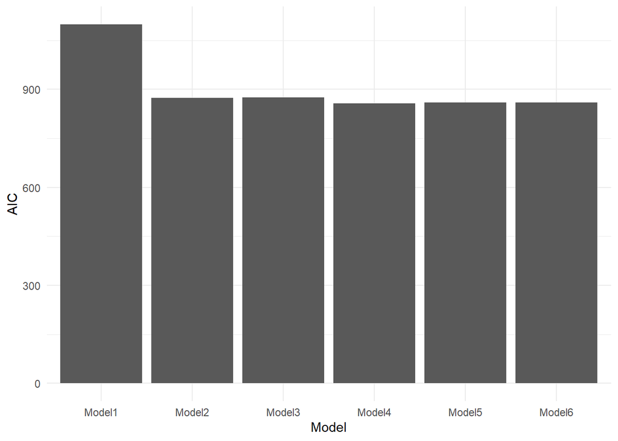

```r
data.frame(
  Model = c("Model1", "Model2", "Model3", "Model4", "Model5", "Model6"),
  AIC = c(Model1$aic, Model2$aic, Model3$aic, Model4$aic, Model5$aic, Model6$aic)
) %>%
  ggplot()+
  geom_bar(aes(x = Model, y = AIC), stat = "identity")+
  theme_minimal()
```

## 12.3. Validating our Model Using the Test Set

We create a new data frame `testSetProbs` that consists of our `class` (e.g. development_change as a 1 or 0), and `probs` - which is the prediction for each observation in our test set using `Model6`. The `type` parameter is set to `response`, which means our `probs` are measures of estimated probability from 0-1.

```r
testSetProbs <-
  data.frame(class = datTest$development_change,
             probs = predict(Model6, datTest, type="response"))
```

This density plot is a key tool to figure out where we will set our threshold for classifying predicted probabilities as 1s or 0s (e.g. Predicted to Develop or Predicted Not To Develop).

Take a close look at this plot and see if you have some ideas about what threshold would separate out our 1s from our 0s most effectively with a minimum of error.

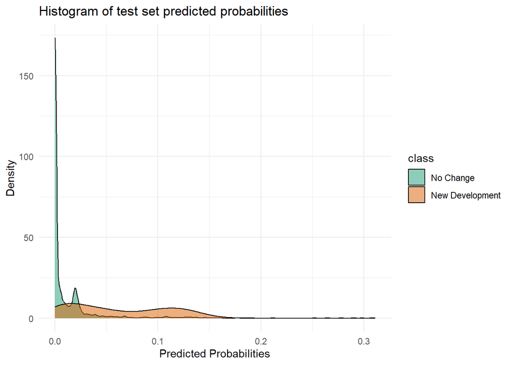

```r
ggplot(testSetProbs, aes(probs)) +
  geom_density(aes(fill=class), alpha=0.5) +
  scale_fill_manual(values = palette2,
                    labels=c("No Change","New Development")) +
  labs(title = "Histogram of test set predicted probabilities",
       x="Predicted Probabilities",y="Density") +
  theme_minimal()
```

### 12.3.1. Confusion matrix

Here, we set 0.05 as our cutoff value - above that value, we predict that cell is a `1`, and below it, a `0`.

We build a confusion matrix to see how accurate this model is overall, and what our error rates are. There are our four potential outcomes:

- True Positive: We predicted a cell would convert from undeveloped to developed and it *did* convert.
- False Positive: We predicted a cell would convert from undeveloped to developed and it *did not* convert.
- True Negative: We predicted a cell would *not* convert from undeveloped to developed and it *did not* convert.
- False Negative: We predicted a cell would *not* convert from undeveloped to developed and it *did* convert.

```r
testSetProbs$predClass  = ifelse(testSetProbs$probs > .05 ,1,0)

caret::confusionMatrix(reference = as.factor(testSetProbs$class),
                       data = as.factor(testSetProbs$predClass),
                       positive = "1")
```

```
## Confusion Matrix and Statistics
##
##           Reference
## Prediction    0    1
##          0 8624   63
##          1  462   59
##
##                Accuracy : 0.943
##                  95% CI : (0.9381, 0.9476)
##     No Information Rate : 0.9868
##     P-Value [Acc > NIR] : 1
##
##                   Kappa : 0.1656
##
##  Mcnemar's Test P-Value : <2e-16
##
##             Sensitivity : 0.483607
##             Specificity : 0.949153
##          Pos Pred Value : 0.113244
##          Neg Pred Value : 0.992748
##              Prevalence : 0.013249
##          Detection Rate : 0.006407
##    Detection Prevalence : 0.056581
##       Balanced Accuracy : 0.716380
##
##        'Positive' Class : 1
##
```

*Model Analysis*

False Negatives (FN) = 63

The confusion matrix indicates that the model is highly effective at identifying cells that remain undeveloped, with a large number of true negatives. However, it struggles to accurately detect actual land conversions, as reflected in the low number of true positives.

### 12.3.2. ROC Curve

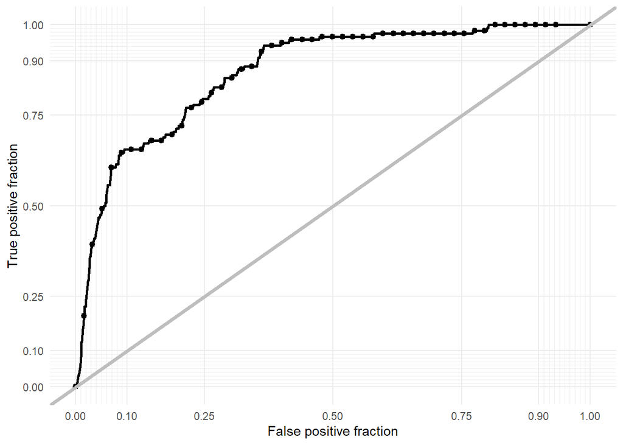

```r
ggplot(testSetProbs, aes(d = as.numeric(class), m = probs)) +
  geom_roc(n.cuts = 50, labels = FALSE) +
  style_roc(theme = theme_grey) +
  geom_abline(slope = 1, intercept = 0, size = 1.5, color = 'grey') +
  theme_minimal()
```

```r
library(plotROC)
# Ensure class is numeric (0 or 1)
testSetProbs$class <- as.numeric(as.character(testSetProbs$class))

# Calculate AUC
roc_plot <- ggplot(testSetProbs, aes(d = class, m = probs)) +
  geom_roc(n.cuts = 50, labels = FALSE)

calc_auc(roc_plot)
```

|  | PANEL | group | AUC |
| --- | --- | --- | --- |
| 1 | 1 | -1 | 0.8692404 |

## 12.4. Analyzing Error

### 12.4.1. Setting a Threshold

```r
dat_2011_preds <-
  dat_2011 %>%
    mutate(probs = predict(Model6, dat_2011, type="response")) %>%
   mutate(Threshold_5_Pct = as.factor(ifelse(probs >= 0.05 ,1,0)),
           Threshold_17_Pct =  as.factor(ifelse(probs >= 0.17 ,1,0))) %>%
  mutate(confResult_05 = case_when(Threshold_5_Pct == 0 & development_change == 0 ~ "True_Negative",
                              Threshold_5_Pct == 1 & development_change==1 ~ "True_Positive",
                              Threshold_5_Pct == 0 & development_change==1 ~ "False_Negative",
                              Threshold_5_Pct == 1 & development_change ==0 ~ "False_Positive")) %>%
  mutate(confResult_17 = case_when(Threshold_17_Pct == 0 & development_change == 0 ~ "True_Negative",
                              Threshold_17_Pct == 1 & development_change==1 ~ "True_Positive",
                              Threshold_17_Pct == 0 & development_change==1 ~ "False_Negative",
                              Threshold_17_Pct == 1 & development_change ==0 ~ "False_Positive")) %>%
  st_as_sf()
```

```r
# Summarize by county and model type
dat_2011_preds %>%
  as.data.frame() %>%
  dplyr::select(confResult_05, confResult_17, NAME) %>%
  pivot_longer(cols = starts_with("confResult"), names_to = "Model_Type", values_to = "Confusion_Result") %>%
  group_by(NAME, Model_Type, Confusion_Result) %>%
  tally() %>%
  pivot_wider(names_from = Confusion_Result, values_from = n, values_fill = 0) %>% # Reshape to wide format
  mutate(TN_Rate_Specificity = 100*( True_Negative/(True_Negative+False_Positive)),
         TP_Rate_Sensitivity = 100*( True_Positive/(True_Positive + False_Negative))) %>%
  dplyr::select(NAME, Model_Type, TN_Rate_Specificity, TP_Rate_Sensitivity) %>%
  kable() %>%
  kable_styling()
```

| NAME | Model_Type | TN_Rate_Specificity | TP_Rate_Sensitivity |
| --- | --- | --- | --- |
| Anson | confResult_05 | 98.56828 | 20.000000 |
| Anson | confResult_17 | 99.77974 | 0.000000 |
| Cabarrus | confResult_05 | 84.77331 | 64.516129 |
| Cabarrus | confResult_17 | 99.91446 | 0.000000 |
| Chester | confResult_05 | 100.00000 | 0.000000 |
| Chester | confResult_17 | 100.00000 | 0.000000 |
| Gaston | confResult_05 | 99.47276 | 0.000000 |
| Gaston | confResult_17 | 100.00000 | 0.000000 |
| Iredell | confResult_05 | 95.80420 | 30.000000 |
| Iredell | confResult_17 | 100.00000 | 0.000000 |
| Lancaster | confResult_05 | 95.48998 | 61.538461 |
| Lancaster | confResult_17 | 100.00000 | 0.000000 |
| Lincoln | confResult_05 | 100.00000 | 16.666667 |
| Lincoln | confResult_17 | 100.00000 | 0.000000 |
| Mecklenburg | confResult_05 | 83.40865 | 78.571429 |
| Mecklenburg | confResult_17 | 99.48354 | 3.571429 |
| Rowan | confResult_05 | 100.00000 | 0.000000 |
| Rowan | confResult_17 | 100.00000 | 0.000000 |
| Union | confResult_05 | 92.39709 | 58.620690 |
| Union | confResult_17 | 99.95157 | 0.000000 |
| York | confResult_05 | 93.38095 | 59.375000 |
| York | confResult_17 | 99.90476 | 0.000000 |
| NA | confResult_05 | NaN | NaN |
| NA | confResult_17 | NaN | NaN |

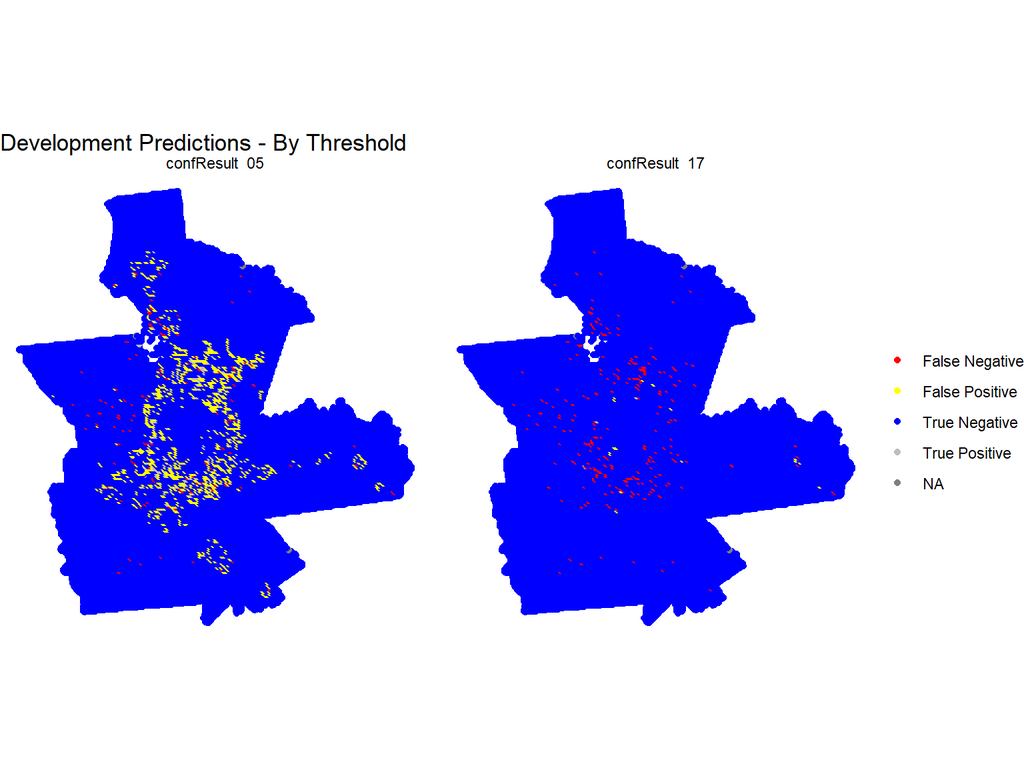

```r
ggplot() +
  geom_sf(data= dat_2011_preds %>%
            st_centroid() %>%
               dplyr::select(confResult_05, confResult_17, geometry) %>%
               gather(key = "Variable", value = "Value", -geometry),
             aes(colour=Value)) +
  facet_wrap(~Variable) +
  scale_colour_manual(values = c("red", "yellow", "blue", "grey"), labels=c("False Negative","False Positive", "True Negative", "True Positive"),
                      name="") +
  labs(title="Development Predictions - By Threshold") +
  theme_void()
```

# 13. Making A Forecast

Here, we propose a path for a new Lynx Silver rail line from South Gastonia in Gaston County, NC to Monroe, NC, the seat of Union County. This route is proposed for several reasons:

- Charlotte currently has two primary light rail lines within Mecklenburg County that serve downtown, but neither runs to the airport. With high visitor volume, business traffic, as well as three professional sports team stadiums located downtown, congestion in the region could be dramatically reduced with the extension of a new light rail line that serves communities to the east and west of downtown and connects them through the airport. The airport is pursuing a $4B expansion campaign that includes a renovated and expanded terminal and new runway, which could be built to serve this rail line.
- The region’s largest population group is 18 to 44 year olds and the median age is 38, demographics that are more likely to utilize public transit. Although Lynx ridership levels are still not back to pre-COVID levels, ridership of the Gold line increased by nearly 14% and the Blue line’s ridership also increased by 12% between 2023 and 2024, indicating there is a market for increased access to public transit.
- Rather than working across state boundaries, it will be easier to keep the line within North Carolina from a financing and implementation standpoint.

```r
silver_line <- st_read("Data_Charlotte/Proposed_Silverline.dbf")
silver_line_proj <- st_transform(silver_line, st_crs(fishnetPopulation19))

# Create a buffer (800 meters = ~2625 feet)
silver_line_buffer <- st_buffer(silver_line_proj, dist = 2625)

# Intersect buffered zone with 2019 fishnet population
pop_served <- fishnetPopulation19[st_intersects(fishnetPopulation19, silver_line_buffer, sparse = FALSE), ]

# Summarize population served
served_summary <- pop_served %>%
  st_drop_geometry() %>%
  summarize(population_served = sum(pop_2019, na.rm = TRUE))

print(served_summary)
```

```
##   population_served
## 1          325429.7
```

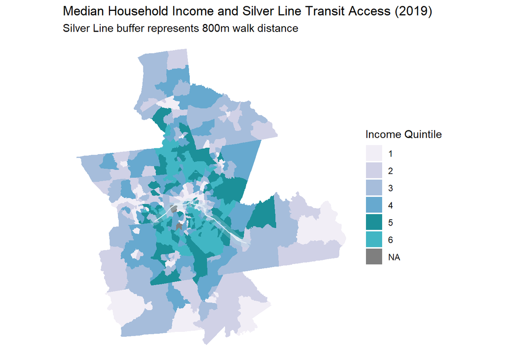

```r
acsVariables2 <- c(
  income = "B19013_001",
  total_pop = "B02001_001",
  white_alone = "B02001_002")

msa_tracts2 <- map_dfr(names(charlotte_msa_counties), function(st) {
  get_acs(
    geography = "tract",
    variables = acsVariables2,
    state = st,
    county = charlotte_msa_counties[[st]],
    survey = "acs5",
    year = 2019,
    output = "wide",
    geometry = TRUE
  )
}) %>%
  st_transform(st_crs(fishnetPopulation19)) %>%
  mutate(
    pct_nonwhite = 100 * (total_popE - white_aloneE) / total_popE,
    income_group = ntile(incomeE, 6),
    race_group = ntile(pct_nonwhite, 6)
  )

##Income map
ggplot() +
  geom_sf(data = msa_tracts2, aes(fill = factor(income_group)), color = NA) +
  scale_fill_manual(values = palette10, name = "Income Quintile") +
  geom_sf(data = silver_line_proj, color = "white", size = 1.2) +
  geom_sf(data = silver_line_buffer, fill = "lightblue", alpha = 0.3, color = NA) +
  labs(
    title = "Median Household Income and Silver Line Transit Access (2019)",
    subtitle = "Silver Line buffer represents 800m walk distance"
  ) +
  theme_void()
```

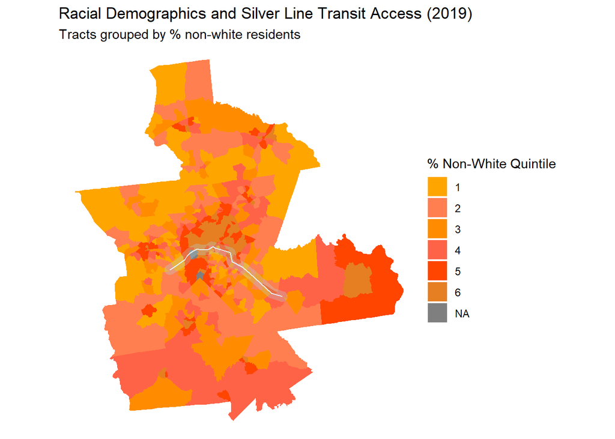

```r
## Race map
ggplot() +
  geom_sf(data = msa_tracts2, aes(fill = factor(race_group)), color = NA) +
  scale_fill_manual(
    values = c("#FFA500", "#FF7F50", "#FF8C00", "#FF6347", "#FF4500", "#E67E22"),
    name = "% Non-White Quintile"
  ) +
  geom_sf(data = silver_line_proj, color = "white", size = 1.2) +
  geom_sf(data = silver_line_buffer, fill = "lightblue", alpha = 0.3, color = NA) +
  labs(
    title = "Racial Demographics and Silver Line Transit Access (2019)",
    subtitle = "Tracts grouped by % non-white residents"
  ) +
  theme_void()
```

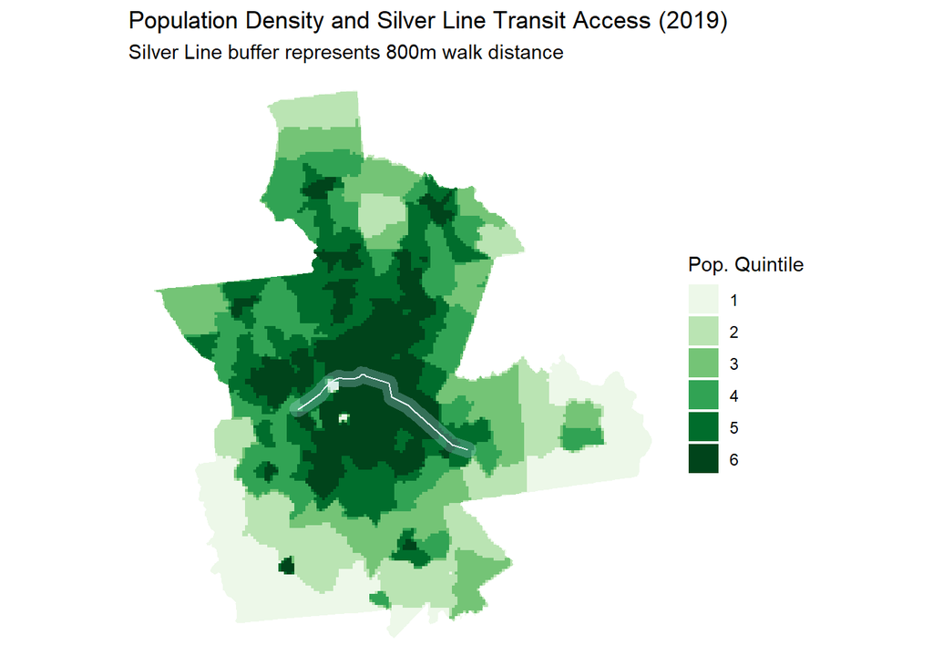

```r
## Population Map

ggplot() +
  geom_sf(data = fishnetPopulation19 %>%
            mutate(pop_quintile = factor(ntile(pop_2019, 6))),
          aes(fill = pop_quintile), color = NA) +
  scale_fill_manual(values = c("#edf8e9", "#bae4b3", "#74c476", "#31a354", "#006d2c", "#00441b"), name = "Pop. Quintile") +
  geom_sf(data = silver_line_proj, color = "white", size = 1.2) +
  geom_sf(data = silver_line_buffer, fill = "lightblue", alpha = 0.3, color = NA) +
  labs(title = "Population Density and Silver Line Transit Access (2019)",
       subtitle = "Silver Line buffer represents 800m walk distance") +
  theme_void()
```

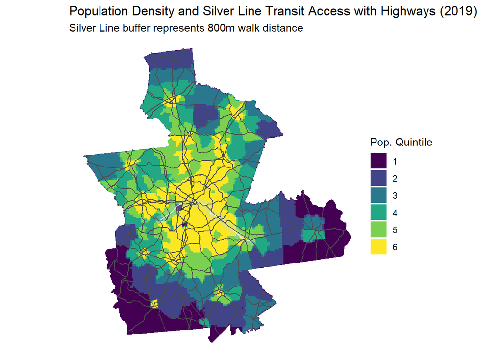

```r
#plotting along with highways to give people currently using a highway an alternate mode of transportation

ggplot() +
  geom_sf(data = fishnetPopulation19 %>%
            mutate(pop_quintile = factor(ntile(pop_2019, 6))),
          aes(fill = pop_quintile), color = NA) +
  scale_fill_viridis_d(name = "Pop. Quintile") +
  geom_sf(data = silver_line_proj, color = "white", size = 1.2) +
  geom_sf(data = silver_line_buffer, fill = "lightblue", alpha = 0.3, color = NA) +
  geom_sf(data = charHighways, color = "gray30", size = 0.5) +
  labs(title = "Population Density and Silver Line Transit Access with Highways (2019)",
       subtitle = "Silver Line buffer represents 800m walk distance") +
  theme_void()
```

*Median Household Income and Silver Line Transit Access* The map illustrates income inequality across the Charlotte MSA, where higher-income households are predominantly concentrated in already developed urban and suburban areas.

*Racial Demographics* This map reveals clear patterns of racial segregation within the MSA. Areas with a higher percentage of non-white residents tend to be spatially clustered and often located in tracts with less infrastructure investment and limited proximity to high-capacity transit corridors.

*Population Density* Population density is heavily concentrated in the urban core, particularly around central Charlotte, and gradually decreases toward the periphery. The second map overlays current highway infrastructure, revealing that even areas with low population density have significant highway connectivity. However, development in these regions remains slow, underscoring the need for expanded public transit and affordable, equitable access to the urban center.

Hence, we are proposing adding a new Lynx Silver line which will serve approximately 325,430 people based on 2019 population data within a 800m/0.5mi walkshed of the line.

```r
dat_2019_sf <- st_as_sf(dat_2019)

silver_line <- st_transform(silver_line, st_crs(dat_2019_sf))
dat_2019_sf <- st_transform(dat_2019_sf, st_crs(silver_line))

centroids <- st_centroid(dat_2019_sf)
dist_to_silver <- as.numeric(st_distance(centroids, st_union(silver_line)))

dat_2019$distance_silver <- dist_to_silver
```

#### Predicting

```r
dat_2027_preds <- dat_2019 %>%
    mutate(probs = predict(Model6, dat_2019, type="response") ,
           Prediction = as.factor(ifelse(probs >= 0.17 ,1,0))) %>%
  st_as_sf()
```

Now let’s map it - where are the cells that are classified as likely to develop by 2027? Note that blank cells are water.

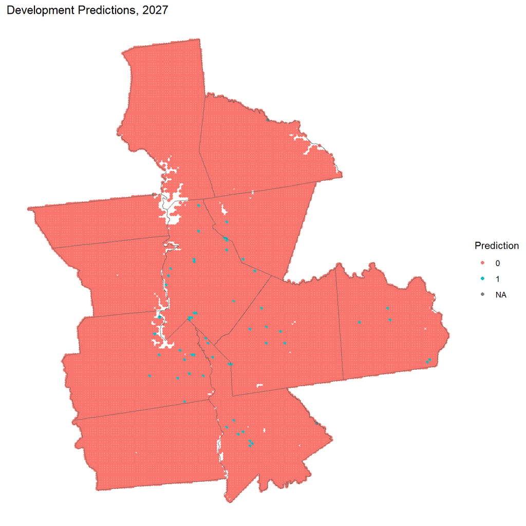

```r
ggplot(data=dat_2027_preds) +
  geom_point(aes(x=xyC(dat_2027_preds)[,1],
                 y=xyC(dat_2027_preds)[,2], colour = Prediction)) +
  geom_sf(data = studyAreaCounties, fill = "transparent")+
  labs(title="Development Predictions, 2027") +
  theme_void()
```

# 14. Assess Impact

Here, we assess the impact of our predictive model - how much development is to be expected in 2027 and where will it occur within the Charlotte region?

## 14.1. Impact Assessment

```r
dat_2027_preds %>%
  as.data.frame() %>%
  filter(Prediction == 1) %>%
  tally() %>%
  rename(total_cells = n) %>%
  mutate(total_area_m = total_cells * res(lc_2019_rs)[1],
         total_km2 = total_area_m/1000000,
         total_mi2 = total_km2*0.386102) %>%
  kable() %>%
  kable_styling ()
```

| total_cells | total_area_m | total_km2 | total_mi2 |
| --- | --- | --- | --- |
| 55 | 49500 | 0.0495 | 0.019112 |

County-by-county forecast:

```r
dat_2027_preds %>%
  as.data.frame() %>%
  filter(Prediction == 1) %>%
  group_by(NAME) %>%
  tally() %>%
  rename(total_cells = n) %>%
  mutate(total_area_m = total_cells * res(lc_2019_rs)[1],
         total_km2 = total_area_m/1000000,
         total_mi2 = total_km2*0.386102) %>%
  kable() %>%
  kable_styling ()
```

| NAME | total_cells | total_area_m | total_km2 | total_mi2 |
| --- | --- | --- | --- | --- |
| Anson | 5 | 4500 | 0.0045 | 0.0017375 |
| Cabarrus | 5 | 4500 | 0.0045 | 0.0017375 |
| Lancaster | 9 | 8100 | 0.0081 | 0.0031274 |
| Mecklenburg | 17 | 15300 | 0.0153 | 0.0059074 |
| Union | 8 | 7200 | 0.0072 | 0.0027799 |
| York | 11 | 9900 | 0.0099 | 0.0038224 |

Forecast by 2019 land cover type:

```r
dat_2027_preds %>%
  as.data.frame() %>%
  filter(Prediction == 1) %>%
  dplyr::select(farm, otherUndeveloped, forest, wetlands, water, NAME) %>%
  gather(-NAME, key = "Variable", value = "Value") %>%
  group_by(NAME, Variable) %>%
  summarize(total_cells = sum(as.numeric(Value))) %>%
  mutate(total_area_m = total_cells * res(lc_2019_rs)[1],
         total_km2 = total_area_m/1000000,
         total_mi2 = total_km2*0.386102) %>%
  kable() %>%
  kable_styling ()
```

| NAME | Variable | total_cells | total_area_m | total_km2 | total_mi2 |
| --- | --- | --- | --- | --- | --- |
| Anson | farm | 0 | 0 | 0.0000 | 0.0000000 |
| Anson | forest | 0 | 0 | 0.0000 | 0.0000000 |
| Anson | otherUndeveloped | 5 | 4500 | 0.0045 | 0.0017375 |
| Anson | water | 0 | 0 | 0.0000 | 0.0000000 |
| Anson | wetlands | 0 | 0 | 0.0000 | 0.0000000 |
| Cabarrus | farm | 0 | 0 | 0.0000 | 0.0000000 |
| Cabarrus | forest | 0 | 0 | 0.0000 | 0.0000000 |
| Cabarrus | otherUndeveloped | 5 | 4500 | 0.0045 | 0.0017375 |
| Cabarrus | water | 0 | 0 | 0.0000 | 0.0000000 |
| Cabarrus | wetlands | 0 | 0 | 0.0000 | 0.0000000 |
| Lancaster | farm | 0 | 0 | 0.0000 | 0.0000000 |
| Lancaster | forest | 0 | 0 | 0.0000 | 0.0000000 |
| Lancaster | otherUndeveloped | 9 | 8100 | 0.0081 | 0.0031274 |
| Lancaster | water | 0 | 0 | 0.0000 | 0.0000000 |
| Lancaster | wetlands | 0 | 0 | 0.0000 | 0.0000000 |
| Mecklenburg | farm | 0 | 0 | 0.0000 | 0.0000000 |
| Mecklenburg | forest | 0 | 0 | 0.0000 | 0.0000000 |
| Mecklenburg | otherUndeveloped | 17 | 15300 | 0.0153 | 0.0059074 |
| Mecklenburg | water | 0 | 0 | 0.0000 | 0.0000000 |
| Mecklenburg | wetlands | 0 | 0 | 0.0000 | 0.0000000 |
| Union | farm | 0 | 0 | 0.0000 | 0.0000000 |
| Union | forest | 0 | 0 | 0.0000 | 0.0000000 |
| Union | otherUndeveloped | 8 | 7200 | 0.0072 | 0.0027799 |
| Union | water | 0 | 0 | 0.0000 | 0.0000000 |
| Union | wetlands | 0 | 0 | 0.0000 | 0.0000000 |
| York | farm | 0 | 0 | 0.0000 | 0.0000000 |
| York | forest | 0 | 0 | 0.0000 | 0.0000000 |
| York | otherUndeveloped | 11 | 9900 | 0.0099 | 0.0038224 |
| York | water | 0 | 0 | 0.0000 | 0.0000000 |
| York | wetlands | 0 | 0 | 0.0000 | 0.0000000 |

# 15. Recommendations

*Planning context* According to the U.S. Census Bureau, the city of Charlotte itself is the 15th most populous city in the US and the MSA is the largest metro area in the Carolinas and fourth largest in the southeastern US. According to the Charlotte Regional Business Alliance, the region’s population has grown by 20% since 2010 and is projected to grow an additional 12% by 2030, with an estimated 117 people moving into the region daily. The region has seen a 16% labor force growth since 2010 and has a lower unemployment rate and higher year-over-year employment change than the US on average, as well as the state averages for NC and SC.

Population and economic growth in the greater Charlotte region are due in part to the city’s role as a major financial center and transportation hub, with headquarters for Bank of America and Truist Financial, as well as the largest employment hub for Wells Fargo. Charlotte’s airport is the sixth busiest in the world, with nonstop destinations to 188 locations and an economic impact of nearly $40 billion.

Charlotte has two primary light rail lines within Mecklenburg County that serve downtown, but neither runs to the airport. With high visitor volume, business traffic, as well as three professional sports team stadiums located downtown, congestion in the region could be dramatically reduced with the extension of a new light rail line that serves communities to the east and west of downtown and connects them through the airport. The airport is pursuing a $4B expansion campaign that includes a renovated and expanded terminal and new runway, which could be built to serve this rail line.

*Analysis Recommendations* *1. Assess a Phased Rail Construction Approach and enable Transit-Oriented Development*

In this analysis, we have forecasted potential development in 2027 in the broader Charlotte region based on land cover change between 2011 and 2019 and proposed creating a new Silver light rail line that would connect Charlotte’s downtown, airport, and communities to the west and east. Because the model was not trained with transit data (existing Blue and Gold Lynx lines), our results show limited support for this full route. We did not include the Lynx transit infrastructure because it has not remained consistent throughout our study time period (2011 - 2019), after discussing with Isabel. However, in an initial run of the model, we did see that proximity to the Blue Line was a strong predictor of development between 2011 and 2019. In retrospect, we should have incorporated at least the initial Blue Line (constructed 2007) into our model, along with highways, to better assess the influence of transit-oriented development. Unfortunately, we ran out of time to go back and try this again!

*2. Consider potential hidden impacts to wetlands.* It is notable that the most common land cover type that experienced development change between 2011 and 2019 is “Other Undeveloped” lands. Additional analysis of soil type or other features of these areas would be extremely useful to determine more specifics. Although these lands could have been already-cleared sites being prepped for construction, it is also very possible that they were emergent wetlands which do not consistently appear wet or vegetated throughout the year. Wetlands are critical ecosystems that provide a variety of services and benefits like wildlife habitat and fisheries breeding grounds; recreation and tourism; flood risk reduction through erosion control, storm surge buffering, and water storage; and water filtering which improves water quality. Each wetland varies in its hydrology, plant community composition, soil types, biogeochemical processes, and other environmental factors. According to the North Carolina Division of Water Resources, riverine forest wetlands, mountain bogs, and pocosins are particularly common wetlands types in the Piedmont Region of the Carolinas, which may be obscured in the NLCD as forest, shrub, or bare land cover.

Wetlands across the US are facing increasing threats of degradation and loss thanks to development, hydrological alteration like levees and dams, invasive species, and sea level rise. In 2023, the North Carolina Legislature passed a law that substantially reduced protections for wetlands, making them more at risk from development pressures. To prevent the loss of these critical habitats and reduce flood risk for residents, implementing additional local restriction on development of wetlands would be beneficial to make up for the protections lost at the state level. In addition to local ordinances, the region could also pursue a wetlands mitigation bank to ensure there is no net loss of wetlands from development.